# Case Studies

Remo Schmutz

2025-08-26

# Introduction

In this document we will not focus on the different software implementations available on CRAN but only on the different versions of cohens D by only using the `effectsize` package to calculate them. This should give us a feeling what potential implications it can have when software implementations do not clearly distinguish the different versions of cohens D, while separating these issues.

# Simulation Study

I used [this comparison](https://github.com/ianhussey/effect-size-distributions-and-extreme-examples/blob/main/code/analysis_comparative.html) in order to motivate the simulation settings.

# Case Study

## Case Study 1: AIID data

### Comparing Estimates

```r
load("../../effect-size-distributions-and-extreme-examples/data/aiid/processed/AIID_subset_confirmatory.RData")

data_trimmed <- AIID_subset_confirmatory %>%
  #filter(exclude_iat_stricter == FALSE) %>%
  filter(english_fluency %in% c("English fluent - speak/read it regularly", "English is my primary language")) |>
  dplyr::select(user_id,
                domain,
                age,
                sex,
                english_fluency,
                exclude_iat_stricter,
                block_order,
                iat_type,
                D,
                # self-report attitudes data
                prefer,
                others_prefer,
                actual_x, actual_y,
                actual_diff,
                gut_x, gut_y,
                # individual differences scales data
                individual_differences_measure,
                individual_differences_sum_score)

dat_r_d_all <- data_trimmed |>
  drop_na(domain, actual_x, actual_y) |>
  group_by(domain) |>
  summarise(n = n(),
            mean_actual_x = mean(actual_x, na.rm = TRUE),
            mean_actual_y = mean(actual_y, na.rm = TRUE),
            sd_actual_x = sd(actual_x, na.rm = TRUE),
            sd_actual_y = sd(actual_y, na.rm = TRUE),
            r_actuals = list(broom::tidy(cor.test(actual_y, actual_x))),
            d_s = list(effectsize::repeated_measures_d(x = actual_x, y = actual_y, method = "d", adjust = TRUE)),
            d_avg = list(effectsize::repeated_measures_d(x = actual_x, y = actual_y, method = "av", adjust = TRUE)),
            d_z = list(effectsize::repeated_measures_d(x = actual_x, y = actual_y, method = "z", adjust = TRUE)),
            d_rm = list(effectsize::repeated_measures_d(x = actual_x, y = actual_y, method = "rm", adjust = TRUE))) |>
  select(domain, d_s, d_avg, d_z, d_rm, r_actuals)

dat_long <- dat_r_d_all |>
  unnest(cols = c(d_s, d_avg, d_z, d_rm, r_actuals), names_sep = ".") |>
    pivot_longer(
    cols = matches("^d_(s|avg|z|rm)\\.(Cohens_d|d_av|d_z|d_rm|CI_low|CI_high)$"),
    names_to      = c("method", "stat"),
    names_pattern = "^d_(s|avg|z|rm)\\.(Cohens_d|d_av|d_z|d_rm|CI_low|CI_high)$",
    values_to     = "value") |>
  select(domain, method, stat, value, r_actuals.estimate) |>
  mutate(
    stat = recode(stat,
                  "Cohens_d" = "Cohens_d",
                  "d_av"     = "Cohens_d",
                  "d_z"      = "Cohens_d",
                  "d_rm"     = "Cohens_d",
                  "CI_low"   = "CI_low",
                  "CI_high"  = "CI_high")) |>
  rename(r = r_actuals.estimate) |>
  pivot_wider(
    names_from  = stat,
    values_from = value)
```

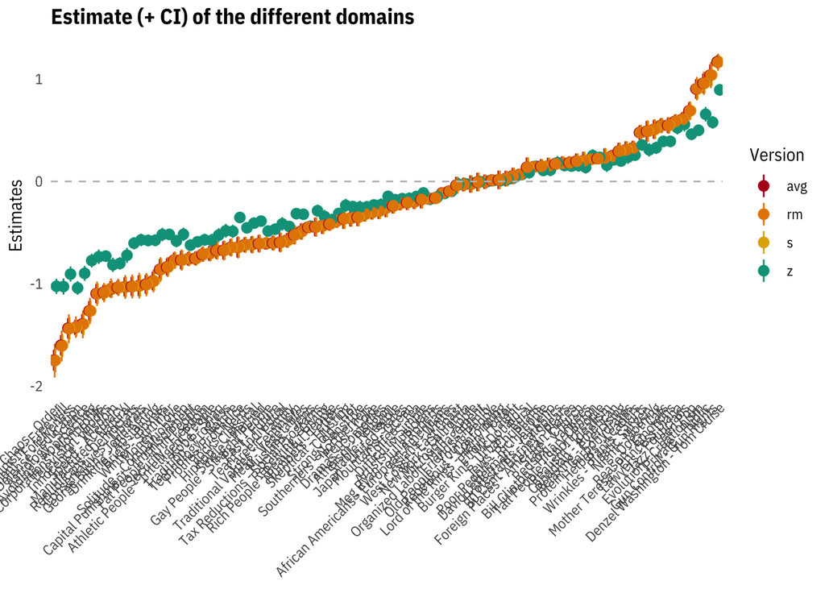

```r
dat_long |>
  mutate(domain = fct_reorder(domain, Cohens_d)) |>
  rename(Version = method) |>
  ggplot(aes(x = domain, y = Cohens_d, ymin = CI_low, ymax = CI_high, color = Version)) +
  geom_pointrange(position = position_dodge(width = 0.5)) +
  scale_color_manual(values = palette) +
  labs(x = NULL,
       y = "Estimates",
       title = "Estimate (+ CI) of the different domains")+
  geom_hline(yintercept = 0, linetype = "dashed", color = "grey") +
  theme(axis.text.x = element_text(angle = 45, hjust = 1))
```

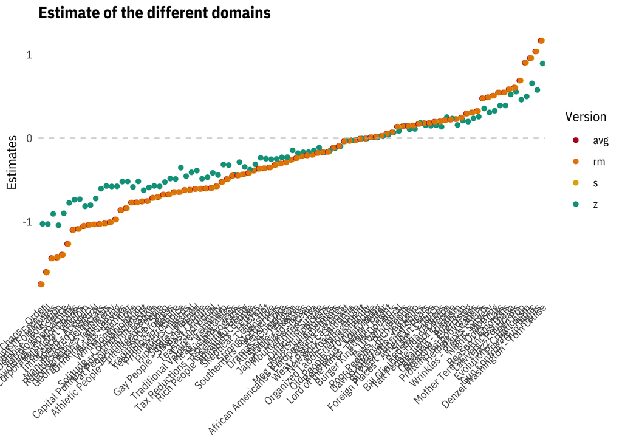

```r
dat_long |>
  mutate(domain = fct_reorder(domain, Cohens_d)) |>
  rename(Version = method) |>
  ggplot(aes(x = domain, y = Cohens_d, color = Version)) +
  geom_point(position = position_dodge(width = 0.5)) +
  scale_color_manual(values = palette) +
 labs(x = NULL,
       y = "Estimates",
       title = "Estimate of the different domains")+
  geom_hline(yintercept = 0, linetype = "dashed", color = "grey") +
  theme(axis.text.x = element_text(angle = 45, hjust = 1))
```

### Individual Differences between versions

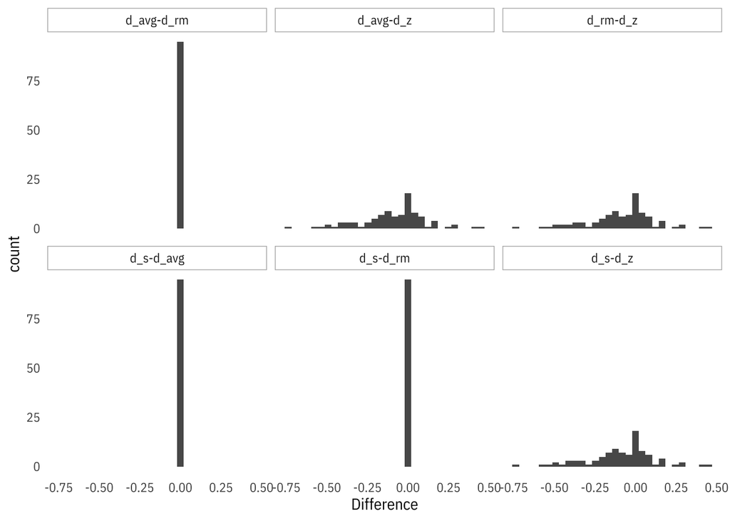

```r
df_differences <- dat_r_d_all |>
  unnest(cols = c(d_s, d_avg, d_z, d_rm), names_sep = ".") |>
  select(domain, d_s.Cohens_d, d_avg.d_av, d_z.d_z, d_rm.d_rm) |>
  mutate(`d_s-d_avg` = d_s.Cohens_d - d_avg.d_av,
         `d_s-d_z` = d_s.Cohens_d - d_z.d_z,
         `d_s-d_rm` = d_s.Cohens_d - d_rm.d_rm,
         `d_avg-d_z` = d_avg.d_av - d_z.d_z,
         `d_avg-d_rm` = d_avg.d_av - d_rm.d_rm,
         `d_rm-d_z` = d_rm.d_rm - d_z.d_z) |>
   pivot_longer(
    cols = c(`d_s-d_avg`, `d_s-d_z`, `d_s-d_rm`, `d_avg-d_z`, `d_avg-d_rm`, `d_rm-d_z`),
    names_to  = "comparison",
    values_to = "Difference")

df_differences |>
  ggplot(aes(x =Difference)) +
  geom_histogram()+
  facet_wrap(~comparison)
```

As we can see, the most difference is between all measures and $d_z$, as a reminder, the denomintator of $d_z$ is calculated as:

$d_z: SD = \sqrt{SD_1^2+SD_2^2-2rSD_1SD_2}$ and we can extract the correction factor as $1/\sqrt{2(1-r)}$. As a first step it is therefore interesting to understand the role of the correction factoer depending on the correlation between measures.

### Correction factor

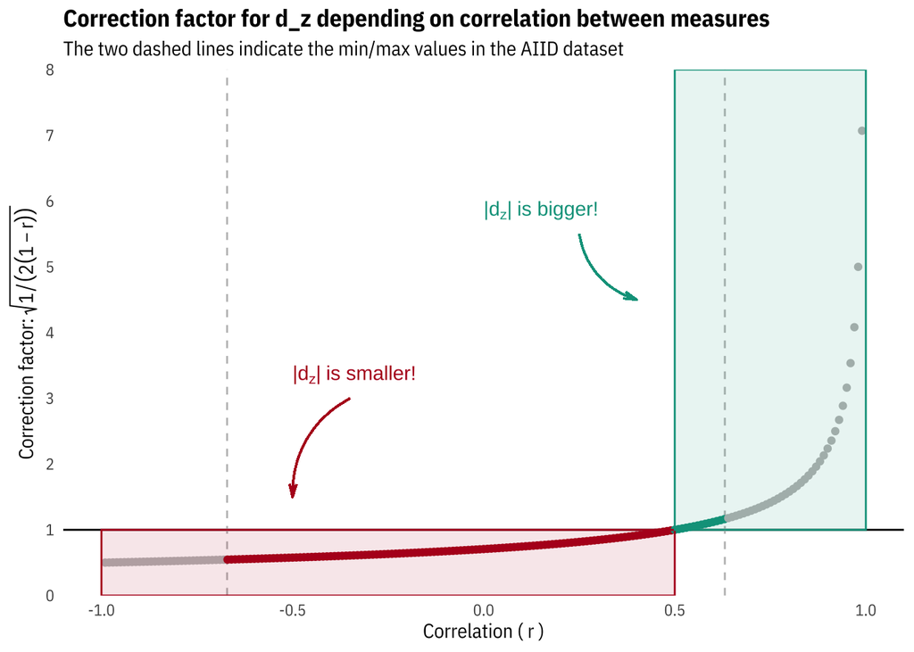

```r
max_r <- max(dat_long$r)
min_r <- min(dat_long$r)

tibble(r = seq(-.99, .99, by = 0.01)) |>
  mutate(
    correction = correct(r),
    color = case_when(
      correction < 1 & r > min_r ~ "negative",
      correction >= 1 & r < max_r ~ "positive",
      TRUE ~ "other")) |>
  ggplot(aes(x = r, y = correction, color = color)) +
  geom_hline(yintercept = 1,  color = "black") +
  geom_vline(xintercept = max_r, linetype = "dashed", color = "grey") +
  geom_vline(xintercept = min_r, linetype = "dashed", color = "grey") +
  geom_point() +
  scale_color_manual(values = c("negative" = palette[1],
                                "positive" = palette[4],
                                "other" = "grey")) +
  annotate(
    geom = "rect", xmin = -1, xmax = .5, ymin = 0, ymax = 1,
    fill = alpha(palette[1], 0.1), color = palette[1], linewidth = .5) +
  annotate(
    geom = "rect", xmin = .5, xmax = 1, ymin = 1, ymax = 8,
    fill = alpha(palette[4], 0.1), color = palette[4], linewidth = .5) +
  annotate(
    geom = "text", x = -.5, y = 3.5,
    label = expression("|d"[z]*"|" ~ "is smaller!"),
    color = palette[1],
    hjust = 0,
    vjust = 1,
    lineheight = 1) +
  geom_curve(
    aes(x = -0.35, xend = -0.5, y = 3, yend = 1.5),
    curvature = 0.3,   # adjust (positive = curve left, negative = curve right)
    arrow = arrow(angle = 15, length = unit(0.5, "lines")),
    color = palette[1],
    linewidth = 0.5) +
  annotate(
    "text", x = 0, y = 6,
    label = expression("|d"[z]*"|" ~ "is bigger!"),
    color = palette[4],
    fontface = "bold",
    hjust = 0,
    vjust = 1,
    lineheight = 1) +
  geom_curve(
    aes(x = 0.25, xend = 0.4, y = 5.5, yend = 4.5),
    curvature = 0.3,   # adjust (positive = curve left, negative = curve right)
    arrow = arrow(angle = 15, length = unit(0.5, "lines")),
    color = palette[4],
    linewidth = 0.5) +
  scale_y_continuous(breaks = seq(0, 10, by = 1), limits = c(0,8), expand = c(0,0)) +
  labs(x = "Correlation ( r )",
       y = expression("Correction factor: " *sqrt(1 / (2 * (1 - r)))),
       title = "Correction factor for d_z depending on correlation between measures",
       subtitle = "The two dashed lines indicate the min/max values in the AIID dataset") +
  guides(color = "none")
```

As we can observe, the correction factor for $d_z$ is not symmetrical around 0, which means that negative- and positive correlations are treated differently. We can also observe that within the bounds of the observed correlations in the AIID dataset, the correction factor is mostly below 1, which means that the absolute value of $d_z$ is in general expected to be smaller than the other versions of cohens D.

What is the distribution of correlations and the corresponding correction factors in the AIID dataset?

```r
dat_r <- dat_r_d_all |>
  unnest(r_actuals, names_sep = ".") |>
  select(domain, r = r_actuals.estimate) |>
  mutate(correction = correct(r),
         percentile_r = percent_rank(r),
         percentile_correction = percent_rank(correction))

# dat_r |>
#   pivot_longer(
#     cols = c(r, correction),
#     names_to  = "measure",
#     values_to = "value") |>
#   ggplot(aes(x = value)) +
#   geom_histogram() +
#   facet_wrap(~measure, scales = "free")
#
# dat_r |>
#   pivot_longer(
#     cols = c(r, correction),
#     names_to  = "measure",
#     values_to = "value") |>
#   mutate(measure = recode(measure,
#                           "r" = "Correlation",
#                           "correction" = "Correction factor")) |>
#   select(domain, measure, value, percentile = percentile_r) |>
#   ggplot(aes(x = value, y = percentile)) +
#   geom_point() +
#   facet_wrap(~measure, scales = "free") +
#   labs(x = "Value",
#        y = "Percentile",
#        title = "Percentile plot of correlation and correction factor") +
#   geom_hline(yintercept = c(0.25, 0.5, 0.75, 0.05, 0.95), linetype = "dashed", color = "grey")
```

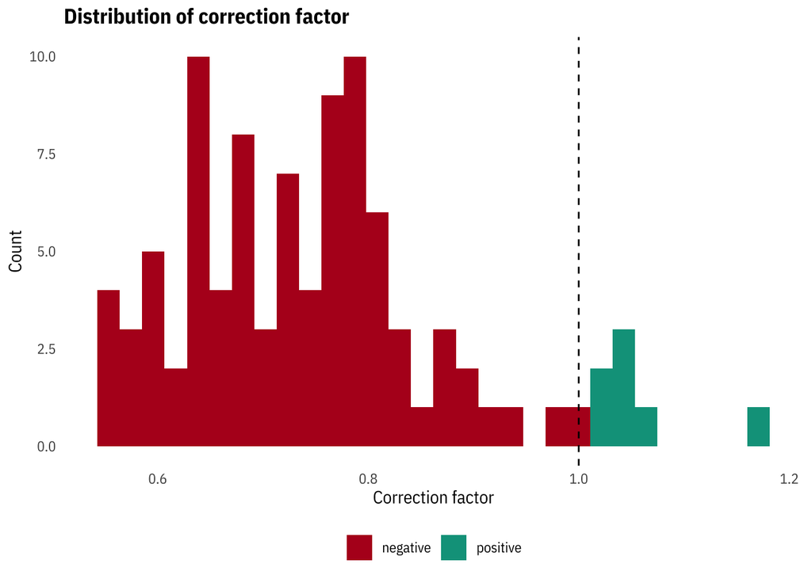

```r
dat_r |>
  select(domain, correction) |>
  mutate(color = if_else(correction < 1, "negative", "positive")) |>
  ggplot(aes(x = correction, fill = color)) +
  geom_histogram(bins = 30) +
  scale_fill_manual(values = c("negative" = palette[1], "positive" = palette[4])) +
  labs(x = "Correction factor",
       y = "Count",
       title = "Distribution of correction factor") +
  theme(legend.title = element_blank(), legend.position = "bottom") +
  geom_vline(xintercept = 1, linetype = "dashed", color = "black")
```

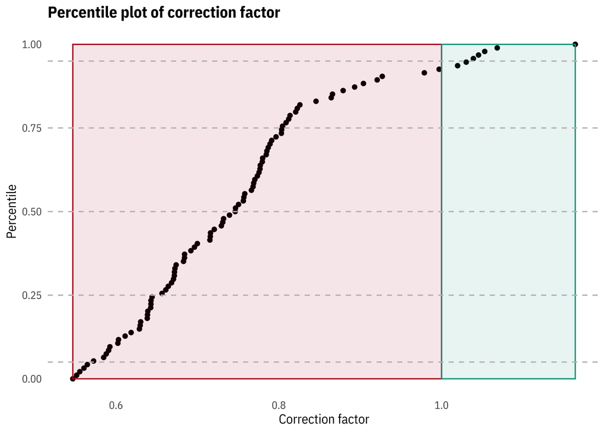

```r
dat_r |>
  select(domain, correction, percentile_correction) |>
  ggplot(aes(x = correction, y = percentile_correction)) +
  geom_point() +
  labs(x = "Correction factor",
       y = "Percentile",
       title = "Percentile plot of correction factor") +
  annotate(
    geom = "rect", xmin = correct(min_r), xmax = 1, ymin = 0, ymax = 1,
    fill = alpha(palette[1], 0.1), color = palette[1], linewidth = .5) +
  annotate(
    geom = "rect", xmin = 1, xmax = correct(max_r), ymin = 0, ymax = 1,
    fill = alpha(palette[4], 0.1), color = palette[4], linewidth = .5) +
  geom_hline(yintercept = c(0.25, 0.5, 0.75, 0.05, 0.95), linetype = "dashed", color = "grey")
```

### Relationship between correlation and differences between versions

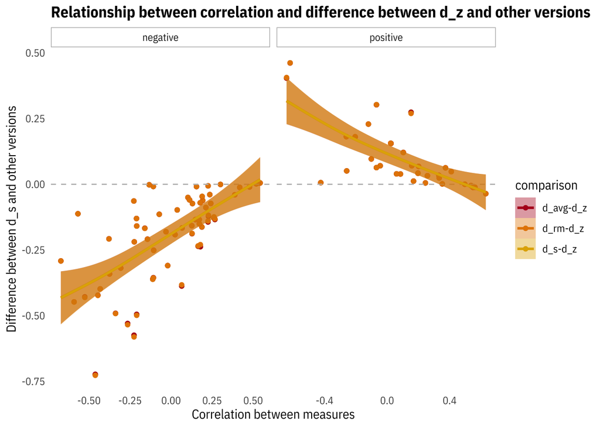

```r
df_check <- df_differences |>
  select(domain, d_s.Cohens_d, comparison, Difference) |>
  rename(d_s = d_s.Cohens_d) |>
  filter(comparison %in% c("d_avg-d_z", "d_s-d_z", "d_rm-d_z")) |>
  left_join(dat_long |> select(domain, r) |> distinct(), by = "domain") |>
  group_by(domain) |>
  mutate(sign = if_else(d_s >= 0, "positive", "negative"))

df_check |>
  ggplot(aes(y = Difference, x = r, color = comparison, fill = comparison)) +
  geom_point() +
  geom_hline(yintercept = 0, linetype = "dashed", color = "grey") +
  geom_smooth(method = "gam", se = TRUE) +
  facet_wrap(~sign, scales = "free_x") +
  labs(y = "Difference between d_s and other versions",
       x = "Correlation between measures",
       title = "Relationship between correlation and difference between d_z and other versions")+
  scale_color_manual(values = palette) +
  scale_fill_manual(values = palette)
```

As we have seen, the correction factor approaches 1 when the correlation approaches 0.5, which means that the differences between the versions should approach 0. This is indeed the case, as we can see in the plot above. The same can be observed when we take the absolute value of the differences.

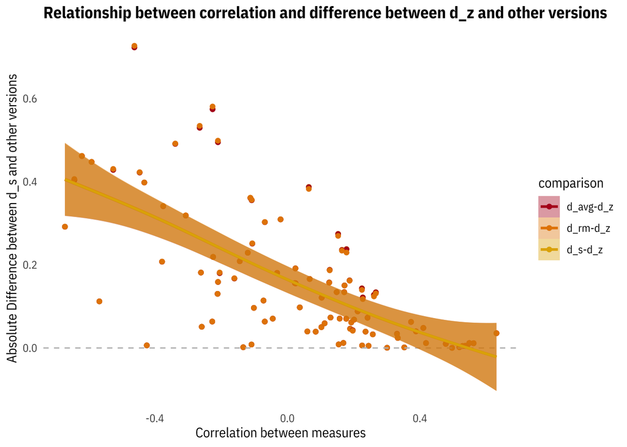

```r
df_check |>
  mutate(Difference = abs(Difference)) |>
  ggplot(aes(y = Difference, x = r, color = comparison, fill = comparison)) +
  geom_point() +
  geom_hline(yintercept = 0, linetype = "dashed", color = "grey") +
  geom_smooth(method = "gam", se = TRUE) +
  labs(y = "Absolute Difference between d_s and other versions",
       x = "Correlation between measures",
       title = "Relationship between correlation and difference between d_z and other versions")+
  scale_color_manual(values = palette) +
  scale_fill_manual(values = palette)
```

### p-hacking strategy?

Now, I want to explore how prevalent it is, that different versions of cohens D lead to different conclusions in terms of statistical significance.

```r
dat_long |>
  mutate(significant = case_when(CI_low > 0 & CI_high > 0 ~ TRUE,
                                 CI_low < 0 & CI_high < 0 ~ TRUE,
                                 .default = FALSE)) |>
  group_by(domain) |>
  filter(length(unique(significant)) != 1) |>   # keep only if all the same
  ungroup() |> gt()
```

| domain | method | r | Cohens_d | CI_low | CI_high | significant |
| --- | --- | --- | --- | --- | --- | --- |

As we can see, this is never the case.